# Assessing Influential Points in Regression

```r
library(tidyverse)
library(pander)
library(mosaic)
library(olsrr)
library(car)
library(DT)
library(robustbase)
library(sjPlot)
library(ggplot2)
library(broom)

outie <- tibble(
  Point = c( 1, 2, 3, 4, 5),
  Value = c(0.8, 2.3, 2.8, 0, 5.3)
)

mydata <- data.frame(
  x = c(1, 2, 3, 4, 5, 6, 7, 8, 9, 10, 20, 23, 4.5, 22),
  y = c(2, 1, 4, 1.3, 3, 5, 4.2, 16.1, 18.2, 20.3,21, 23,40,56))
```

# Objectives

In this document we will discuss…

1. Leverage and points that should be classified as overly influential on the regression parameter estimates and removed from a regression.
2. Cook’s Distance measurement for points in a regression.
3. Apply robust regression to mitigate the effects of outliers.

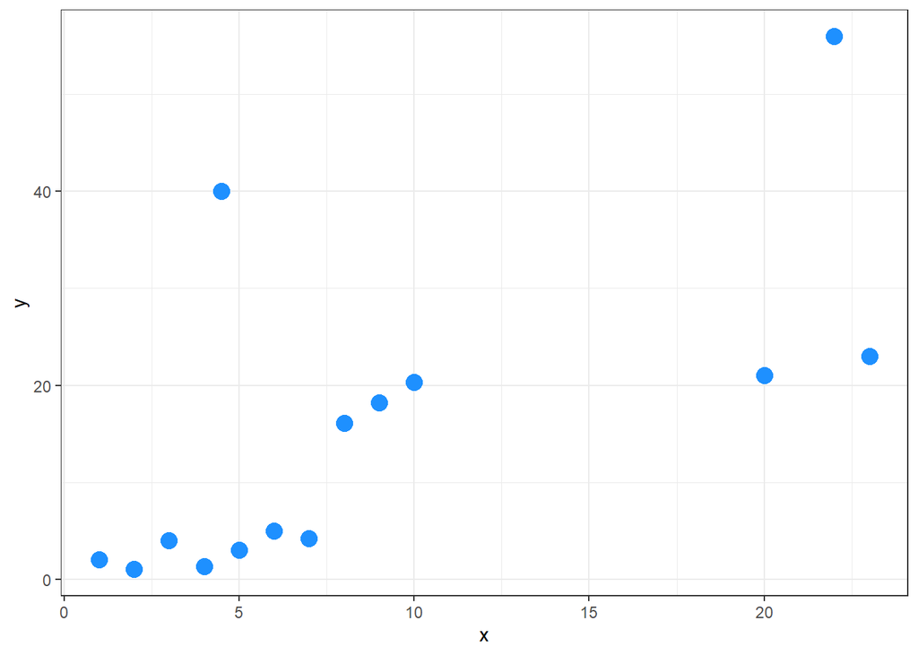

```r
ggplot(mydata, aes(x=x, y=y)) +
  geom_point(color = "dodgerblue", pch = 19, size = 4) +
  theme_bw()
```

# Outliers

Linear regressions can be SUPER sensitive to unusual data: outliers, high leverage values, or a combination of the two. **Outliers** are the points that fall far from the other data points and or the visual pattern seen in a scatter plot. Through their deviation from the overall pattern, they can pull and effect the regression line to give us both an inaccurate visual representation and statistical results of the regression. In this *Residuals vs. Leverage* plot, it compares a point’s leverage (x-axis) and studentized residuals (y-axis, standardizes the residuals by dividing them by an estimate of its standard deviation) to identify the different types of unusual points.

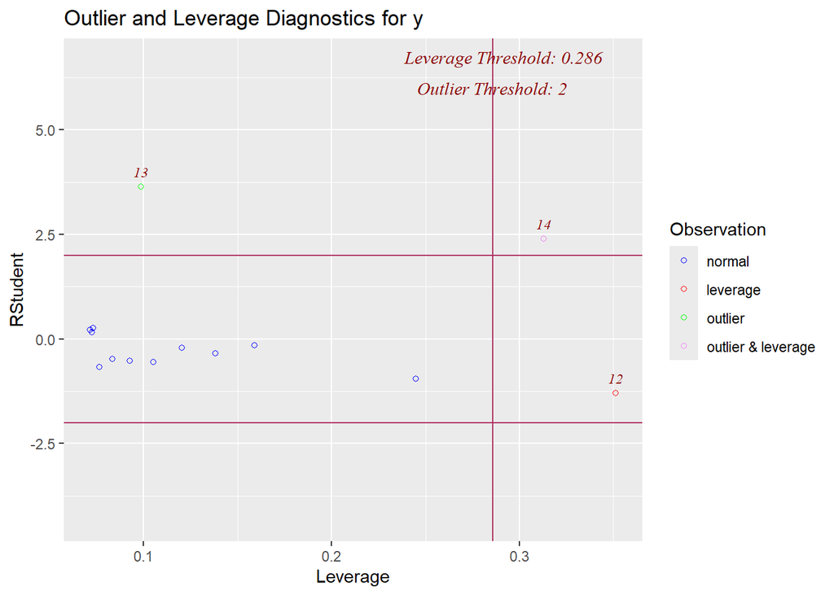

```r
library(grid)

model <- lm(y ~ x, data = mydata)

ols_plot_resid_lev(model)
```

Identifying these outliers can be visually easy within smaller data sets and simpler regression. Yet, as the regressions get more complex and the data sets become more extensive, then locating these negatively effecting points can get tedious and difficult.

Fortunately, there are two sources of measurement, **Cook’s Distance and Leverage Values**, that can help us detect and quantify the presence of these outliers. Additionally, once we can confirm the existence of outliers and their influence in a data set, we can use **Robust Regression** to lessen their effect and give us accurate and interpretative results.

# Leverage Values

**Leverage/Influential points** are measures *how extreme a data point’s predictor values (its x-values) are compared to the rest of the data set* using values between 1 and 0.

- 1 : lots of leverage / pulling the regression towards itself (falls outside the overall pattern, being highly influential)
- 0 : just “one of many”, not unduly influencing the regression line

*Click through the tabs to explore this concept more in depth*

### Mathematical Perspective

Mathematically, there are a lot of layers when it comes to understanding leverage values. But follow along and I will explain every step of the way!

##### 1) Starting Point: Simple Linear Regression

The foundation is the basic linear regression equation that relates a response variable to a predictor:

$$Y_i = \beta_0 + \beta_1 X_i + \epsilon_i$$

##### 2) Vector Representation

- In our model, each variable ($Y_i$, $X_i$, and $\epsilon_i$) represents an individual observation at position i. The coefficients $\beta_0$ and $\beta_1$ measure the relationships between variables. To account for all n observations in our dataset, we use vectors instead of individual values. A column of 1’s is included alongside $\beta_0$ to represent the intercept term.

$$\left[ \begin{array}{c} Y_1 \\ Y_2 \\ \vdots \\ Y_n\end{array}\right]
= \beta_0 \left[ \begin{array}{c} 1 \\
1 \\
\vdots \\ 1 \end{array}\right] + \beta_1 \left[\begin{array}{c} X_1
\\ X_2 \\ \vdots \\ X_n \end{array}\right] + \left[\begin{array}{c}
\epsilon_1 \\ \epsilon_2 \\ \vdots \\ \epsilon_n \end{array}\right]$$

##### 3) Matrix Organization

- Once we have our variables in vector form, we can arrange them into a matrix. This matrix combines our predictor variables (both intercept and slope) with our parameter vector ($\beta_0$ and $\beta_1$), creating an organized structure for our calculations.

$$\left[ \begin{array}{c} Y_1 \\ Y_2 \\ \vdots \\ Y_n\end{array}\right]
= \left[ \begin{array}{cc} 1 & X_1\\
1 & X_2 \\
\vdots & \vdots \\
1 & X_n \end{array}\right] \left[\begin{array}{c} \beta_0 \\
\beta_1 \end{array}\right] + \left[\begin{array}{c} \epsilon_1 \\
\epsilon_2 \\ \vdots \\ \epsilon_n \end{array}\right]$$

##### 4) Simplified Vector Notation

- We can then express our matrix equation more concisely using arrow notation:

$$\vec{Y} = \mathbf{X}\vec{\beta} + \vec{\epsilon}$$

##### 5) Sum of Squared Errors (SSE)

- While our model can accommodate various combinations of $\beta_0$ and $\beta_1$, our goal is to find the specific values that minimize the Sum of Squared Errors (SSE). The SSE quantifies how well our model fits the data by measuring the total deviation of our predictions from the actual values. A smaller SSE indicates more accurate predictions.
- Thus, our SSE can be written as the following notation:

$$\sum_{i=1}^n \epsilon_i ^2$$

##### 6) Vector Expression of SSE

- We can express the Sum of Squared Errors more elegantly using vector notation. By multiplying the error vector ($\vec{\epsilon}$) by its transpose ($\vec{\epsilon}^t$), we compute the sum of squared errors. This multiplication effectively squares each error term, giving us an equivalent expression to $\epsilon^2$.

$$\vec{\epsilon}^t \vec{\epsilon} = \sum_{i=1}^n \epsilon_i ^2$$

##### 7) Rearranging for Error Vector

- Starting with our original equation from step 4, we can isolate the error vector $\vec{\epsilon}$. Since this equation contains $\vec{\epsilon}$, we can substitute it into our SSE formula to create a comprehensive expression for the error term.

$$\vec{\epsilon} = \vec{Y} - \mathbf{X}\vec{\beta}$$

$$\sum_{i=1}^n \epsilon_i^2 = \vec{\epsilon}^t \vec{\epsilon} = (\vec{Y} -
\mathbf{X}\vec{\beta})^t (\vec{Y} - \mathbf{X}\vec{\beta})$$

##### 8) Taking the Derivate

- To find the optimal values for our coefficients ($\vec{\beta}$) that minimize SSE, we use calculus. By taking the derivative of the SSE function, we can determine where the rate of change equals zero, indicating the point of minimum error. This process involves matrix calculus and leads us to the values that best fit our observed data.

$$\frac{d}{d\mathbf{\beta}} (\mathbf{Y} - \mathbf{X}\mathbf{\beta})^T
(\mathbf{Y} - \mathbf{X}\mathbf{\beta})$$

$$(\mathbf{Y} - \mathbf{X}\mathbf{\beta})^T (\mathbf{Y} -
\mathbf{X}\mathbf{\beta}) = (\mathbf{Y}^T -
\mathbf{\beta}^T\mathbf{X}^T) (\mathbf{Y} - \mathbf{X}\mathbf{\beta})$$

$$= \mathbf{Y}^T\mathbf{Y} - \mathbf{Y}^T\mathbf{X}\mathbf{\beta} -
\mathbf{\beta}^T\mathbf{X}^T\mathbf{Y} +
\mathbf{\beta}^T\mathbf{X}^T\mathbf{X}\mathbf{\beta}$$
$$\frac{d}{d\mathbf{\beta}} (\mathbf{Y}^T\mathbf{Y} -
\mathbf{Y}^T\mathbf{X}\mathbf{\beta} -
\mathbf{\beta}^T\mathbf{X}^T\mathbf{Y} +
\mathbf{\beta}^T\mathbf{X}^T\mathbf{X}\mathbf{\beta})$$

$$\frac{d}{d\mathbf{\beta}} (\mathbf{Y} - \mathbf{X}\mathbf{\beta})^T
(\mathbf{Y} - \mathbf{X}\mathbf{\beta}) = 0 - \mathbf{X}^T\mathbf{Y} -
\mathbf{X}^T\mathbf{Y} + 2\mathbf{\beta}^T\mathbf{X}^T\mathbf{X}$$
$$= -2\mathbf{X}^T\mathbf{Y} + 2\mathbf{X}^T\mathbf{X}\mathbf{\beta}$$
$$= -2\mathbf{X}^T(\mathbf{Y} - \mathbf{X}\mathbf{\beta})$$

Overall, our process has led us to this result that we can then rewrite in the simlar notation of vectors:

$$\frac{d}{d\mathbf{\beta}} (\mathbf{Y} - \mathbf{X}\mathbf{\beta})^T
(\mathbf{Y} - \mathbf{X}\mathbf{\beta}) = -2\mathbf{X}^T(\mathbf{Y} -
\mathbf{X}\mathbf{\beta})$$

$$\frac{d}{d\vec{\beta}}(\vec{Y} - \mathbf{X}\vec{\beta})^t (\vec{Y} -
\mathbf{X}\vec{\beta}) = -2\mathbf{X}^t(\vec{Y} - \mathbf{X}\vec{\beta})$$

##### 9) Setting Derivative to Zero

- To minimize the SSE, we set our derived function equal to a zero vector and solve for the beta vector. This mathematical step helps us find the coefficients that will produce the smallest possible error in our model.

$$-2\mathbf{X}^t(\vec{Y} - \mathbf{X}\vec{\beta}) = \vec{0} \\
-2\mathbf{X}^t\vec{Y} = -2\mathbf{X}^t\mathbf{X}\vec{\beta} \\
\frac{-2\mathbf{X}^t\vec{Y}}{-2} =
\frac{-2\mathbf{X}^t\mathbf{X}\vec{\beta}}{-2} \\
\mathbf{X}^t\vec{Y} = \mathbf{X}^t\mathbf{X}\vec{\beta} \\
(\mathbf{X}^t\mathbf{X})^{-1} * (\mathbf{X}^t\vec{Y}) =
(\mathbf{X}^t\mathbf{X}\vec{\beta}) * (\mathbf{X}^t\mathbf{X})^{-1} \\
(\mathbf{X}^t\mathbf{X})^{-1}\mathbf{X}^t\vec{Y} = \vec{\beta}$$

##### 10) Estimating Beta Coefficients

- We replace the beta vector ($\beta$) with a lowercase b vector to indicate these are estimates rather than true population parameters. These estimated coefficients represent how much our dependent variable changes for each one-unit increase in an independent variable, holding all other variables constant.

$$\vec{b} = (\mathbf{X}^t\mathbf{X})^{-1}\mathbf{X}^t\vec{Y}$$

##### 11) Predicted Values

- To complete our model, we replace Y with Ŷ (Y-hat) to indicate these are predicted values rather than actual observations. This notation clarifies that our model generates estimates based on our data rather than exact values.

$$\hat{\vec{Y}} = \mathbf{X}\vec{b}$$

##### 12) Combining Equations

- By substituting our b vector into the original equation, we can express our predicted values (Ŷ) in terms of what’s known as the *Hat Matrix*. This matrix transformation connects our observed values to their predictions.

$$\hat{\vec{Y}} = \mathbf{X}\vec{b} \leftarrow \vec{b} =
(\mathbf{X}^t\mathbf{X})^{-1}\mathbf{X}^t\vec{Y} \\
\hat{\vec{Y}} =
\mathbf{X}(\mathbf{X}^t\mathbf{X})^{-1}\mathbf{X}^t\vec{Y}$$

##### 13) The Hat Matrix

The Hat Matrix transforms observed values into predicted values. Its diagonal elements ($h_{ii}$) are called leverage values, which measure how much influence each data point has on the model’s predictions. These values quantify how strongly each observation “pulls” the regression line toward itself.

$$\mathbf{H} = \mathbf{X}(\mathbf{X}^t\mathbf{X})^{-1}\mathbf{X}^t$$

$$\hat{\vec{Y}} = \mathbf{H}\vec{Y}$$

### Demonstrated in R

Thankfully, we don’t have to go through that entire calculation process when we instead have the `hatvalues(lmname)` function in R Studio to calculate these for us! Additionally, we can graphically depict them as well with `plot(lmname, which=5)

```r
out.lm <- lm(Value ~ Point, data=outie)

hatvalues(out.lm) %>% pander()
```

| 1 | 2 | 3 | 4 | 5 |
| --- | --- | --- | --- | --- |
| 0.6 | 0.3 | 0.2 | 0.3 | 0.6 |

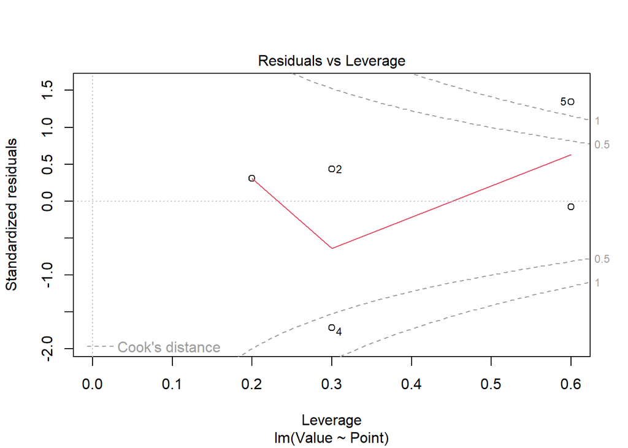

```r
plot(out.lm, which=5)
```

With this graph, another thing that it visually shows is the **Cook’s Distance** of each points, and its with points that have high leverage and large Cook’s Distance that we should reconsider for accuracy or possibly removing from the regression. *But what is Cook’s Distance?*

### Real Life Analogy

*Think of a group photo where everyone is standing together.* Most people (leverage value close to 0) are just part of the group, blending in with others.

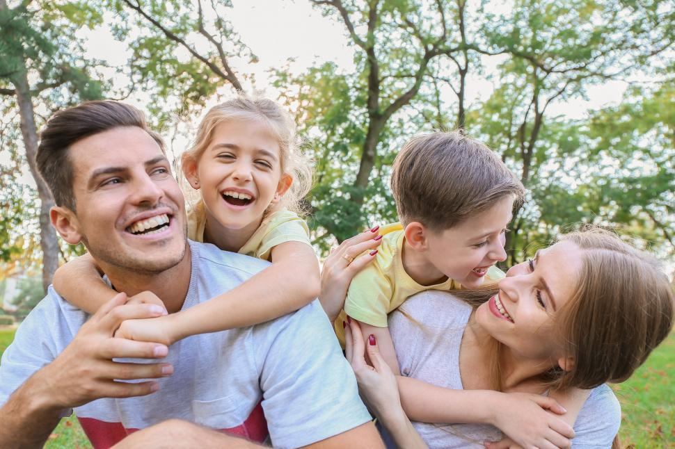

However, *imagine one person standing far off to the side by themselves* (leverage value close to 1).

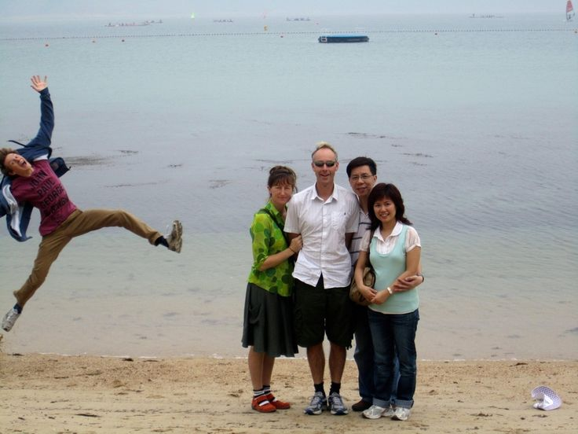

When you try to frame the photo, you have to adjust the WHOLE composition just to include that one person - they’re “pulling” the frame towards them, *just like a high-leverage point pulls the regression line towards itself*.

# Cook’s Distances

**Cook’s Distance** is a statistical diagnostic tool used in regression analysis to identify influential data points that might disproportionately affect the results of a regression model. It combines two key concepts when measuring the impact each individual point has on the regression estimates:

1. Outlyingness : how unusual a data point is
2. Leverage: how much influence a data point has on the regression line due to its position (as looked at previously)

*Click through the tabs to explore this concept more in depth*

### Mathematical Perspective

Calculating Cook’s Distance mathematically can be visualized with the following steps:

1. **Given a data set**

Cars predicting car price based on different x/predictor values.

```r
mtcarz <- mtcars %>%
  select(mpg, cyl, disp, hp, drat, wt)

set.seed(123)
mtcarz$salesprice <- sample(15000:30000, nrow(mtcarz), replace = TRUE)

datatable(mtcarz, options = list(
            pageLength = 3,
            lengthMenu = c(3,10,30)))
```

|  | mpg | cyl | disp | hp | drat | wt | salesprice |
| --- | --- | --- | --- | --- | --- | --- | --- |
| Mazda RX4 | 21 | 6 | 160 | 110 | 3.9 | 2.62 | 17462 |
| Mazda RX4 Wag | 21 | 6 | 160 | 110 | 3.9 | 2.875 | 17510 |
| Datsun 710 | 22.8 | 4 | 108 | 93 | 3.85 | 2.32 | 25418 |
| Hornet 4 Drive | 21.4 | 6 | 258 | 110 | 3.08 | 3.215 | 23717 |
| Hornet Sportabout | 18.7 | 8 | 360 | 175 | 3.15 | 3.44 | 27482 |
| Valiant | 18.1 | 6 | 225 | 105 | 2.76 | 3.46 | 17985 |
| Duster 360 | 14.3 | 8 | 360 | 245 | 3.21 | 3.57 | 16841 |
| Merc 240D | 24.4 | 4 | 146.7 | 62 | 3.69 | 3.19 | 24333 |
| Merc 230 | 22.8 | 4 | 140.8 | 95 | 3.92 | 3.15 | 18370 |
| Merc 280 | 19.2 | 6 | 167.6 | 123 | 3.92 | 3.44 | 28540 |

[output cut: 22 more lines]

2. **Computing the Model

```r
set.seed(373)
mtcarz$salesprice_yhat <- sample(15000:30000, nrow(mtcarz), replace = TRUE)

datatable(mtcarz, options = list(
            pageLength = 3,
            lengthMenu = c(3,10,30)))
```

|  | mpg | cyl | disp | hp | drat | wt | salesprice | salesprice_yhat |
| --- | --- | --- | --- | --- | --- | --- | --- | --- |
| Mazda RX4 | 21 | 6 | 160 | 110 | 3.9 | 2.62 | 17462 | 25461 |
| Mazda RX4 Wag | 21 | 6 | 160 | 110 | 3.9 | 2.875 | 17510 | 15471 |
| Datsun 710 | 22.8 | 4 | 108 | 93 | 3.85 | 2.32 | 25418 | 18337 |
| Hornet 4 Drive | 21.4 | 6 | 258 | 110 | 3.08 | 3.215 | 23717 | 29084 |
| Hornet Sportabout | 18.7 | 8 | 360 | 175 | 3.15 | 3.44 | 27482 | 17468 |
| Valiant | 18.1 | 6 | 225 | 105 | 2.76 | 3.46 | 17985 | 19143 |
| Duster 360 | 14.3 | 8 | 360 | 245 | 3.21 | 3.57 | 16841 | 25668 |
| Merc 240D | 24.4 | 4 | 146.7 | 62 | 3.69 | 3.19 | 24333 | 29647 |
| Merc 230 | 22.8 | 4 | 140.8 | 95 | 3.92 | 3.15 | 18370 | 18987 |
| Merc 280 | 19.2 | 6 | 167.6 | 123 | 3.92 | 3.44 | 28540 | 29355 |

[output cut: 22 more lines]

3. **Now we will see if one specific car had an impact on the data set by excluding it from this new calculation**

Produces another y hat, but it is now y hat “i”, with “i” being that specific car/ data point that we took out (the row we excluded) - This process will repeat as many time as there are rows in the data set

```r
set.seed(287)
mtcarz$salesprice_yhat_withoutspecificcar <- sample(15000:30000, nrow(mtcarz), replace = TRUE)

datatable(mtcarz, options = list(
            pageLength = 3,
            lengthMenu = c(3,10,30)))
```

|  | mpg | cyl | disp | hp | drat | wt | salesprice | salesprice_yhat | salesprice_yhat_withoutspecificcar |
| --- | --- | --- | --- | --- | --- | --- | --- | --- | --- |
| Mazda RX4 | 21 | 6 | 160 | 110 | 3.9 | 2.62 | 17462 | 25461 | 26556 |
| Mazda RX4 Wag | 21 | 6 | 160 | 110 | 3.9 | 2.875 | 17510 | 15471 | 18817 |
| Datsun 710 | 22.8 | 4 | 108 | 93 | 3.85 | 2.32 | 25418 | 18337 | 18975 |
| Hornet 4 Drive | 21.4 | 6 | 258 | 110 | 3.08 | 3.215 | 23717 | 29084 | 20388 |
| Hornet Sportabout | 18.7 | 8 | 360 | 175 | 3.15 | 3.44 | 27482 | 17468 | 15578 |
| Valiant | 18.1 | 6 | 225 | 105 | 2.76 | 3.46 | 17985 | 19143 | 21001 |
| Duster 360 | 14.3 | 8 | 360 | 245 | 3.21 | 3.57 | 16841 | 25668 | 21370 |
| Merc 240D | 24.4 | 4 | 146.7 | 62 | 3.69 | 3.19 | 24333 | 29647 | 16149 |
| Merc 230 | 22.8 | 4 | 140.8 | 95 | 3.92 | 3.15 | 18370 | 18987 | 27032 |
| Merc 280 | 19.2 | 6 | 167.6 | 123 | 3.92 | 3.44 | 28540 | 29355 | 27226 |

[output cut: 22 more lines]

4. **We can then use those values to calculate the Cook’s Distance!**

With that, the Cook’s Distance can be explained by the following mathematical model:

##### Without Explainations

$$D_i = \frac{
\sum^n_{j=1}(\hat{Y_j} - \hat{Y}_{j(i)})^2}{p * MSE}$$

##### With Explainations

$$\underbrace{D_i}_\text{Cook's Distance} = \frac{
\overbrace{\sum^n_{j=1}}^\text{The sum of the differences
between}(\overbrace{\hat{Y_j}}^\text{Predicted value summed up with all
rows} - \overbrace{\hat{Y}_{j(i)}}^\text{Predicted values excluding
"i"})^2}{\underbrace{p}_\text{# of columns/ coefficients}
⋅\underbrace{MSE}_\text{Mean Squared Error}}$$

**Mean Squared Error (MSE)** is the measurement of the average squared difference between predicted and actual values. Mathematically, it can be expressed as this:

$$MSE = \frac{\overbrace{SSE}^\text{Sum of Squared Errors}}{n-p}$$

**Sum of Squared Errors (SSE)** measures the amount of variability that is NOT explained by the model. The mathematical break down of that is:

$$SSE = \underbrace{\sum_{i=1}^n}_\text{The sum of}
(\underbrace{Y_i}_\text{Observed Value(The Dots)} -
\underbrace{\hat{Y_i}}_\text{Predicted Value (The Line)})^2$$